# Assignment 4: Mini Exploratory Report

Will Geiken

11/11/2020

# Introduction

This report explores snowshoe hare data collected in the Bonanza Creek Experimental Forest from 1998 to 2012 (Kielland et al. 2017). In addition to assessing any temporal changes in hare population sizes, this study assesses spatial variations between hare sexes and weights across three catch sites. Further analysis on the relationships between hare sex and weight as well as hind foot length and weight are included to better understand population-wide variation.

# Data and Analysis

Snowshoe hare data were collected and made available by Dr. Knut Kielland and colleagues at the Bonanza Creek Long Term Ecological Research (LTER) network site in the Tanana valley in Alaska, US. The data include 3197 observations from capture-recapture snowshoe hare collection conducted from 1998-2012. This report only includes capture date, weight, sex, and hind foot length data for juvenile-age hares. Hares were trapped in three locations including the Bonanza riparian, the Bonanza mature, and the Bonanza site. Bonanza riparian (bonrip) is a flood zone along the Tanana River, and Bonanza mature (bonmat) is a mature forest approximately one km inland from the river and two km from the riparian plot. The Bonanza site (bonbs) was located in a mature lowland black spruce stand. Following exploratory data visualization, a two-sample t-test with a significance level ($\alpha$) of 0.05 is used to assess differences in mean weight between hare sexes. The difference between sexes are described by Cohen’s *d* effect size. The relationship between weight and hind foot length among all catches is assessed using a linear regression and a Pearson’s r value is calculated to assess the strength of that relationship. All analyses are in R version 4.0.2 using RStudio version 1.3.1056.

# Exploratory Findings

### A. Annual Juvenile Hare Trap Counts

In total 378 juvenile snowshoe hares were observed through capture-recapture efforts from 1998-2012 (Figure 1).

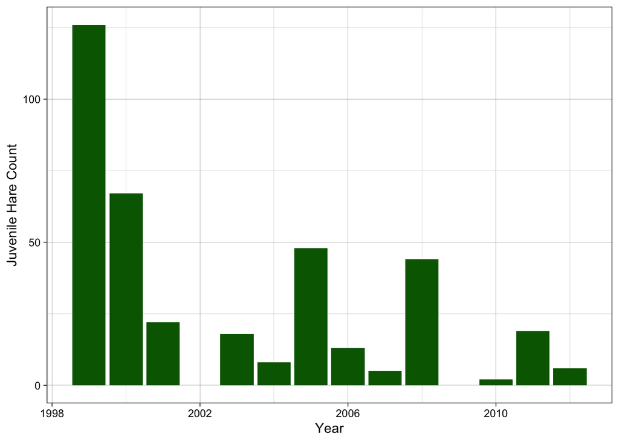

**Figure 1.** Total annual counts of juvenile snowshoe hare catches (including capture and recapture) across all collection sites from 1998-2012. Data: Kielland et al. 2017

##### Major Takeaways

The year with the highest count of juvenile hares was 1999 with 126 juveniles caught, while the lowest were 1998, 2002, and 2009 each with 0 juveniles caught. Proceeding from 1999, the number of juvenile catches declined during and then oscillated at lower counts for the remaining years. The mean annual juvenile catch was 25.2, but that value belies the high year-to-year variation. Additionally, these values do not take into account the number of days spent trapping per year, the number of traps per site, and other statistics relevant to effort. If data collection continues, it would help to standardize data collection effort to avoid biasing trap counts for certain years or at certain sites. No responsible conclusive statements about annual variation can be drawn from the data as they exist.

### B. Visualize Juvenile Hare Weights

Distributions of weights for snowshoe hares at each site are relatively normal and symmetric for most populations, but others feature large skews. Most notably, the male sample at the bonbs site is skewed towards heavier weights while the female population at the bonmat site is skewed towards lighter weights (Figure 2).

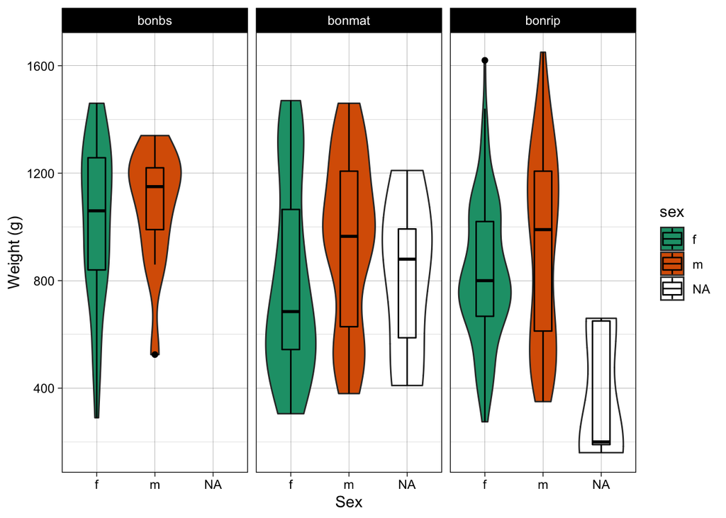

##### Major Takeaways

There is a wide spread in weights across sexes at each of the sites. Within that spread there are a few trends, including that the mean male weights measured were higher than the mean female weights at each of the sites. The mean weights for both male and females at the bonbs site were also higher than the mean weights for any group at the remaining sites. However, the sample sizes varied greatly across sites, and it is entirely possible that the higher mean weights at bonbs are a function of the small sample sizes as opposed to a regional difference.

### C. Juvenile weight comparison

**Table 1.** Descriptive statistics (mean, standard deviation, and sample size) for male and female juvenile snowshoe hare weights (g). Data: Kielland et al. 2017.

| Sex | Mean weight (g) | Standard deviation(g) | Sample size |
| --- | --- | --- | --- |
| f | 855.3909 | 292.2526 | 197 |
| m | 945.8589 | 333.2151 | 163 |

##### Major Takeaways

On average female juvenile snowshoe hares weighed less than juvenile males (855.39 $\pm$ 292.25 and 945.86 $\pm$ 333.22 g, respectively; mean $\pm$ 1 standard deviation) The absolute difference in means was 90.468 g (a 10.05% difference), and that difference was shown to be significant at p < 0.01 (Welch’s two-sample t-test: t(325.02) = -2.71, p = 0.0071). However, the effect size of that difference is fairly small (Cohen’s *d* = -0.29), meaning that the observed difference cannot responsibly be attributed strictly to sex and requires further investigation. Additionally, finding a significant result (i.e. such a small p-value) isn’t surprising given the large sample sizes. Finally, the male weight data is somewhat abnormally distributed, which suggests that the assumptions necessary to even conduct this analysis may not have been met.

### D. Relationship between juvenile weight and hind foot length

The relationship between hind foot length and weight are explored in juvenile snowshoe hares across sex, and further analysis should include a range of additional variables, including sex. It is important to note that diagnostic plots (not included) reveal abnormal and heteroscedastic residual distribution. As such, the assumptions necessary to run a linear regression are not satisfactorily met, but a linear regression is run irregardless.

The simple linear regression reveals that hind foot length significantly predicts juvenile hare weight (p < 0.001, R<sup>2</sup> = 0.299) with an average slope of $\beta$ = 9.523 g/mm (i.e. for every 1 mm increase in hind foot length we expect an average increase in weight of 9.523 g) (Figure 3). Hind foot length and weight are only moderately but significantly, positively correlated (Pearson’s *r* = 0.5466).

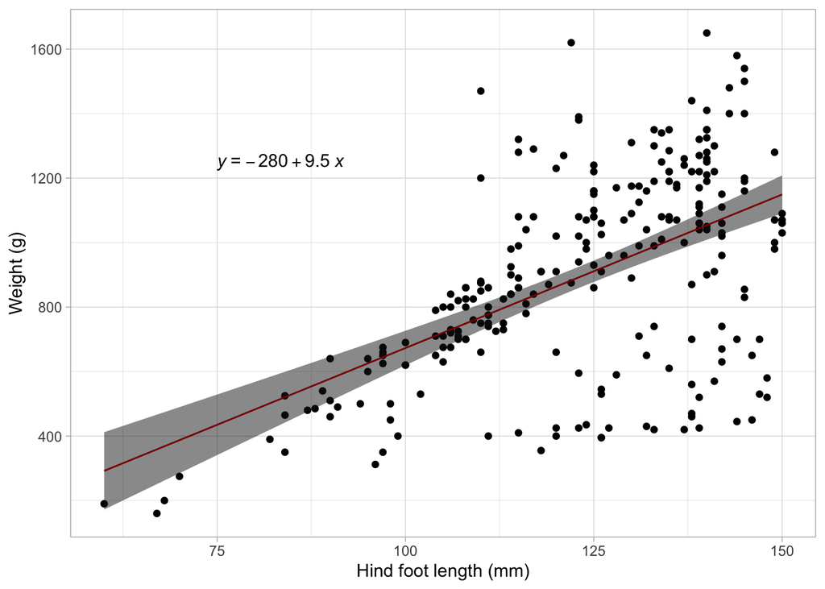

**Figure 3.** Relationship between juvenile snowshoe hare hind foot length (mm) and weight (g). Points indicate individual hares. Linear model summary: $\beta$ = 9.523 g/mm, p < 0.001, R<sup>2</sup> = 0.299, Pearson’s *r* = 0.5466. Data: Kielland et al. 2017

##### Major Takeaways

A significant regression model was found ($\beta$ = 9.523, F(1,247) = 105.2, p < 0.001) with an R<sup>2</sup> of 0.299. This means that 29.9% of variation in juvenile hare weight is explained by its hind foot length. The correlation for this relationship is a moderately positive correlation (Pearson’s *r* = 0.5466), which means that increased hind foot length is moderately correlated with increased weight. However, there are problems with the data that suggest a linear regression should not be conducted. Firstly, the residual distribution is heteroscedastic, with the spread of the residual value increasing across the span of the model, which suggests that the relationship between the two variables is not linear to begin with. Furthermore, the Q-Q plot for the model returns a non-linear result, which means that the residuals are not normally distributed compared to theoretical normal values. For both of those reasons, the assumptions necessary for a linear regression have not been met, and any results drawn from the linear regression conducted are unlikely to accurately represent the populations studied.

# Summary

Based on the data collected and the results of the analysis, making strong claims about the trends or relationships examined is irresponsible. While there does appear to be a decrease in juvenile snowshoe hare populations over time based on sample sizes, those numbers are not averaged by effort. Additionally, the differences in mean weights across observed trapping sites might be due to the small sampling size at individual sites as opposed to a difference caused by an individual site. That is compounded by the evidence that the data spread within juvenile weights is large. Furthermore, the base assumptions necessary to compare the mean weights across sexes and the linear regression between hind foot length and weight were not adequately met. As such, the results of both calculations are questionable. Future work should focus on addressing the confounding variable of effort as well as investigating alternative relationships within the populations.

# Citations

Kielland, K., F.S. Chapin, R.W. Ruess, and Bonanza Creek LTER. 2017. Snowshoe hare physical data in Bonanza Creek Experimental Forest: 1999-Present ver 22. Environmental Data Initiative. https://doi.org/10.6073/pasta/03dce4856d79b91557d8e6ce2cbcdc14 (Accessed 2020-11-17).